# Twitter Hate Speech and Offensive Langage Detection

Please uncomment this to install the required packages:

```
!pip3 install wordsegment
!pip3 install wordcloud
!pip3 install gensim
!pip3 install nltk
!pip3 install yellowbrick
`
```

Please uncomment this to download the `nltk` requirements:

```
import nltk
nltk.download('stopwords')
nltk.download('punkt')
nltk.download('wordnet');
```

```python
import re
import string

import numpy as np
import pandas as pd
import wordsegment as ws
import matplotlib.pyplot as plt
import seaborn as sns

from wordcloud import WordCloud

from nltk.corpus import stopwords
from nltk.tokenize import word_tokenize

from nltk.stem.porter import PorterStemmer

from sklearn.feature_extraction.text import CountVectorizer, TfidfVectorizer
from gensim.models import Word2Vec

from sklearn.model_selection import train_test_split, StratifiedKFold
from sklearn.pipeline import Pipeline
from sklearn.model_selection import GridSearchCV
from sklearn.linear_model import LogisticRegression
from sklearn.metrics import classification_report, plot_confusion_matrix
from sklearn.ensemble import RandomForestClassifier, GradientBoostingClassifier

from yellowbrick.model_selection import FeatureImportances

from joblib import dump, load

RANDOM_STATE = 123
```

## Loading the data set

We load the **[Davidson et al. (2017)](https://github.com/t-davidson/hate-speech-and-offensive-language)** data set containing 24 783 tweets labeled by CrowdFlower users as hate speech, offensive language or neither.

```python
df = pd.read_csv('labeled_data.csv', usecols=range(1, 7))
```

The data set consists of 6 columns:

- `count` - the number of CrowdFlower users who labeled the tweet
- `hate_speech` - the number of CrowdFlower users who labeled the tweet as hate speech
- `offensive_language` - the number of CrowdFlower users who labeled the tweet as offensive language
- `neither` - the number of CrowdFlower users who labeled the tweet as neither
- `class` - the final label (determined by the majority of users who labeled that tweet)
- `tweet` - the content of the tweet

Our focus will be on the `tweet` and `class` columns.

```python
df.head()
```

|  | count | hate_speech | offensive_language | neither | class | tweet |
| --- | --- | --- | --- | --- | --- | --- |
| 0 | 3 | 0 | 0 | 3 | 2 | !!! RT @mayasolovely: As a woman you shouldn't... |
| 1 | 3 | 0 | 3 | 0 | 1 | !!!!! RT @mleew17: boy dats cold...tyga dwn ba... |
| 2 | 3 | 0 | 3 | 0 | 1 | !!!!!!! RT @UrKindOfBrand Dawg!!!! RT @80sbaby... |
| 3 | 3 | 0 | 2 | 1 | 1 | !!!!!!!!! RT @C_G_Anderson: @viva_based she lo... |
| 4 | 6 | 0 | 6 | 0 | 1 | !!!!!!!!!!!!! RT @ShenikaRoberts: The shit you... |

The `class` variable is categorical and uses the following encoding:

- 0 - hate speech
- 1 - offensive language
- 2 - neither

```python
df['class'] = df['class'].astype('category')
```

## Data exploration

```python
df.describe()
```

|  | count | hate_speech | offensive_language | neither |
| --- | --- | --- | --- | --- |
| count | 24783.000000 | 24783.000000 | 24783.000000 | 24783.000000 |
| mean | 3.243473 | 0.280515 | 2.413711 | 0.549247 |
| std | 0.883060 | 0.631851 | 1.399459 | 1.113299 |
| min | 3.000000 | 0.000000 | 0.000000 | 0.000000 |
| 25% | 3.000000 | 0.000000 | 2.000000 | 0.000000 |
| 50% | 3.000000 | 0.000000 | 3.000000 | 0.000000 |
| 75% | 3.000000 | 0.000000 | 3.000000 | 0.000000 |
| max | 9.000000 | 7.000000 | 9.000000 | 9.000000 |

The `class` histogram shows that we are dealing with imbalanced classes. Most tweets were labeled as offensive language, and only a small number of them as hate speech.

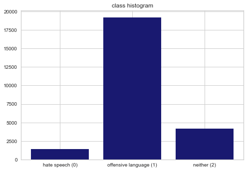

```python
labels = ['hate speech (0)', 'offensive language (1)', 'neither (2)']
counts = df['class'].value_counts(sort=False)

plt.title('class histogram')
plt.bar(x=labels, height=counts, color="midnightblue");
```

The word cloud for all tweets shows that words generally used in sexist, racist, and homophobic contexts appear frequently in the data, as can be expected.

"RT" and "t co" also appear quite often, but they are Twitter-specific terms which don't seem to be useful in our case ("RT" being an abbreviation of ReTweet, and "t co" being a part of `http://t.co` since Twitter automatically shortens all tweet URLs to that). They will be handled during preprocessing.

```python
stop_words = set(stopwords.words('english')) | {"i'm", "'m"}
```

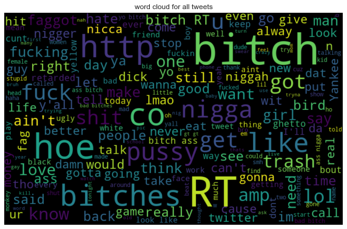

```python
all_tweets = ' '.join([tweet for tweet in df['tweet']])

wc = WordCloud(width=800, height=500, max_font_size=100, stopwords=stop_words,
               random_state=RANDOM_STATE).generate(all_tweets)

plt.figure(figsize=(10, 7))
plt.imshow(wc, interpolation="bilinear")
plt.title('word cloud for all tweets')
plt.axis('off')
plt.show()
```

The word clouds per class shows that the frequencies of racist, homophobic, and sexist slurs are almost equally high for tweets labeled as hate speech. On the other hand, offensive language tweets have a high frequency of predominantly sexist slurs. Tweets that are neither hate speech nor offensive language often contain neutral words such as "bird" or "yellow", but also "trash" which could be considered offensive depending on the context.

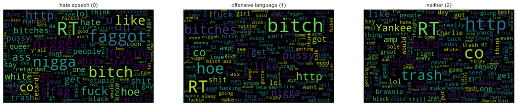

```python
label_meaning = {0: 'hate speech', 1: 'offensive language', 2: 'neither'}

fig, ax = plt.subplots(1, 3, figsize=(20, 14))

for label, meaning in label_meaning.items():
    tweets = ' '.join([tweet for tweet in df['tweet'][df['class'] == label]])

    wc = WordCloud(width=800, height=500, max_font_size=100, stopwords=stop_words,
                   random_state=RANDOM_STATE).generate(tweets)

    ax[label].imshow(wc, interpolation="bilinear")
    ax[label].set_title(f'{meaning} ({label})')
    ax[label].axis('off')
```

## Preprocessing

Since tweets aren't necessarily just plain text but could contain elements like URLs, mentions, symbols, emojis, and hashtags, along with Twitter-specific words like RT and FAV, we'll have to preprocess them using the `preprocess` method.

URLs, mentions, symbols, emojis and special words will be removed since they don't seem to be useful for our classification task.

Hashtags, on the other hand, could contain text that is relevant for a given tweet's classification, so we'll use word segmentation to split them into words. Each hashtag will then be replaced by a string of the obtained words separated by whitespaces.

```python
ws.load()
```

```python
def preprocess(tweet):
    """
    Handles common tweet elements:

    - URLs, mentions, symbols, emojis, and special words (RT, FAV) are removed,
    - hashtags are replaced with the words they consist of.
    """
    patterns_to_remove = {
        'url_pattern': r'https?:\/\/(www\.)?[-a-zA-Z0-9@:%._\+~#=]{1,256}\.'
                       r'[a-zA-Z0-9()]{1,6}\b([-a-zA-Z0-9()@:%_\+.~#?&//=]*)',
        'special_words_pattern': r'\b(?<![@#])(RT|FAV)\b',
        'mention_pattern': r'@[\w-]+',
        'symbol_emoji_pattern': r'&(#\d+|\w+);'
    }
    hashtag_pattern = r'#(\w+)'

    processed_tweet = re.sub('|'.join(patterns_to_remove.values()), '', tweet)
    processed_tweet = re.sub(hashtag_pattern,
                             lambda m: ' '.join(ws.segment(m.group())),
                             processed_tweet)

    return processed_tweet
```

Tweets will be converted to tokens based on `nltk`'s `word_tokenize`. The tokens are lowercased and stemmed using `nltk`'s `PorterStemmer`. Extra whitespaces, punctuation, and stopwords are removed.

```python
punctuation = set(string.punctuation) | {'``', '\'\''}

stop_words = set(stopwords.words('english')) | {"i'm", "'m"}
for stopword in stopwords.words('english'):
    stop_words |= set(word_tokenize(stopword))

stemmer = PorterStemmer()

def tokenize(tweet):
    """
    Returns tokens obtained from the given tweet.

    The tokens are lowercased. Extra whitespaces, punctuation, and stopwords are removed.
    """
    tweet = re.sub(r'\s+|\.\.+', ' ', tweet)
    tokens = [stemmer.stem(word) for word in word_tokenize(tweet.lower())
              if word not in punctuation and word not in stop_words]

    return tokens
```

```python
tokenized_tweets = df['tweet'].apply(preprocess).apply(tokenize)
```

## Tweets to features

Tweets will be extracted to features using three different methods: Bag-of-Words, TF-IDF, and Word2Vec.

### Bag-of-Word features

The simplest way of representing tweets as features is by encoding them as vectors of token frequencies (counts) of all the unique tokens in the data set. The frequency of a token is the number of occurrences of that token in a given tokenized tweet. In the general case, we would thus obtain a `num_tweets` x `num_unique_tokens_in_data` matrix for the data set. This representation is sparse since each tweet contains only a very small number of tokens.

We chose to limit the number of features to 10 000 (i.e. only the 10 000 highest frequencies will be taken into account), and to consider not only unigrams but also bigrams and trigrams (in other words, tokens and sequences of 2 and 3 adjacent tokens).

```python
count_vect = CountVectorizer(
    tokenizer=tokenize,
    preprocessor=preprocess,
    ngram_range=(1, 3),
    max_features=10000
)
```

### TF-IDF features

A more complex way of converting tweets to features is the TF-IDF method. Here we would also obtain a `num_tweets` x `num_unique_tokens_in_data` matrix for the data set (in the general case), but now both the occurences of a token in a single tweet and in the entire data set are taken into account. Such a representation is also sparse.

As before, we limited the number of features to 10 000 and used unigrams, bigrams, and trigrams.

```python
tfidf_vect = TfidfVectorizer(
    tokenizer=tokenize,
    preprocessor=preprocess,
    ngram_range=(1, 3),
    use_idf=True,
    smooth_idf=False,
    norm=None,
    max_features=10000
)
```

### Word2Vec features

Word2Vec is a popular method of text representation that uses a neural network model to obtain dense vectors for each token in the data set.

We chose (through trial and error) to create token vectors of length 500, ignore all tokens with under 10 total occurrences, and use a context window of size 5.

```python
w2v_model = Word2Vec(
    tokenized_tweets,
    size=500,
    window=5,
    min_count=10,
    seed = 123
)

w2v_model.train(tokenized_tweets, total_examples=len(df['tweet']), epochs=20)
```

```
(2576899, 3751040)
```

Since each token is a vector, using them directly for tweet representation would result in a vector or vectors. This is why we'll use the average of the token vectors found in a tweet as that tweet's Word2Vec representation.

```python
def w2v_tweet(tokenized_tweet, size):
    """
    Converts a tokenized tweet into a Word2Vec tweet of the given size.

    The Word2Vec tweet is the average of all the word2vec vectors
    of tokens found in the tweet.
    """
    vector = np.zeros(size)
    count = 0

    for token in tokenized_tweet:
        try:
            vector += w2v_model.wv[token]
            count += 1
        except KeyError:
            continue

    if count != 0:
        vector /= count

    return vector
```

```python
w2v_tweets = np.zeros((len(tokenized_tweets), 500))

for i, tokenized_tweet in enumerate(tokenized_tweets):
    w2v_tweets[i, :] = w2v_tweet(tokenized_tweet, 500)

w2v_tweets.shape
```

```
(24783, 500)
```

## Models

Three classification models were chosen based on their good performance on similar hate speech detection problems (**[Ayo et al. (2020)](https://www.sciencedirect.com/science/article/pii/S1574013720304111)**) $-$ Logistic Regression, Random Forest, and Gradient Boosting. Additionally, these models allow for tuning to avoid overfitting in case of high dimentional datasets, which is our case, and they are pretty simple and easy to interpret.

We chose one hyperparameter per model to tune through `GridSearchCV`, as this task requires a lot of computational power.

### Logistic Regression

```python
def logistic_regression_gscv(X_train, y_train, file_path='results/logreg.gscv'):
    """
    Returns GridSearchCV results for logistic regression on the given training set.

    The results are saved to file using the specified file_path.
    """
    pipeline = Pipeline([
        ('clf', LogisticRegression(class_weight='balanced', penalty='l2',
                                   max_iter=1000, random_state=RANDOM_STATE))
    ])

    pg = {
        'clf__C': [0.001, 0.01, 0.1, 1, 10],
    }

    cv = StratifiedKFold(n_splits=5).split(X_train, y_train)
    gscv = GridSearchCV(estimator=pipeline, param_grid=pg, cv=list(cv),
                        n_jobs=-1, verbose=2).fit(X_train, y_train)

    dump(gscv, file_path)

    return gscv
```

### Random forest

```python
def random_forest_gscv(X_train, y_train, file_path='results/rf.gscv'):
    """
    Returns GridSearchCV results for random forest on the given training set.

    The results are saved to file using the specified file_path.
    """
    pipeline = Pipeline([
        ('clf', RandomForestClassifier(n_estimators=150, class_weight="balanced",
                                       random_state=RANDOM_STATE))
    ])

    pg = {
        'clf__max_depth': [100, 50, 20, 15, 10],
    }

    cv = StratifiedKFold(n_splits=5).split(X_train, y_train)
    gscv = GridSearchCV(estimator=pipeline, param_grid=pg, cv=list(cv),
                        n_jobs=-1, verbose=2, scoring="recall_macro").fit(X_train, y_train)

    dump(gscv, file_path)

    return gscv
```

### Gradient Boosting

```python
def gradient_boosting_gscv(X_train, y_train, file_path='results/gb.gscv'):
    """
    Returns GridSearchCV results for gradient boosting on the given training set.

    The results are saved to file using the specified file_path.
    """
    pipeline = Pipeline([
        ('clf', GradientBoostingClassifier(n_estimators=150, max_depth=5, max_features=30,
                                           random_state=RANDOM_STATE))
    ])

    pg = {
        'clf__learning_rate': [1, 0.75, 0.5, 0.2, 0.15, 0.1],
    }

    cv = StratifiedKFold(n_splits=5).split(X_train, y_train)
    gscv = GridSearchCV(estimator=pipeline, param_grid=pg, cv=list(cv),
                        n_jobs=-1, verbose=2, scoring="recall_macro").fit(X_train, y_train)

    dump(gscv, file_path)

    return gscv
```

# Results

```python
# makes a directory "results" if not exists
!mkdir -p results
```

```python
# auxiliary function for visualizing feature importance
def plot_n_most_important_features(viz, n):
    """Uses a FeatureImportances instance to plot the n most important features."""
    data = pd.DataFrame(data=viz.feature_importances_, index=viz.features_,
                    columns=["Feature Importance"]).reset_index()
    data.rename({"index": "Feature"}, axis=1, inplace=True)

    fig, ax = plt.subplots(figsize=(10,10))
    sns.barplot(data=data.nlargest(n, "Feature Importance"),
                x="Feature Importance", y="Feature", color="midnightblue")
```

Results for each combination of feature representation and classification model are shown below.

The data set was first split into training and test sets (80-20 split), after which the training set was split into 5 subsets, keeping the proportions of each label the same as for the original data set. `GridSearchCV` trained a model for each combination of the 5 subsets and model parameters, of which we chose to select and analyse the best found model.

Models were evaluated on the test set using standard performance metrics:

- precision $-$ the fraction of cases where the model correctly predicted the label $l$ out of all the cases where it predicted $l$,
- recall $-$ the fraction of cases where the model correctly predicted $l$ out of all of the cases where the label actually is $l$,
- F1-score $-$ a weighted harmonic mean of precision and recall, where the 1.0 is the best score is 1.0 and 0.0 the worst.

These metrics were especially useful since we are dealing with an imbalanced data set. Confusion matrices were plotted to help visualize the performance.

## 1) Bag-of-Words representation

```python
X_train, X_test, y_train, y_test = train_test_split(
    count_vect.fit_transform(df['tweet']),
    df['class'],
    test_size=0.2,
    random_state=RANDOM_STATE,
    stratify=df['class']
)
```

```python
bow_inverse_vocab = {v: k for k,v in count_vect.vocabulary_.items()}
```

### 1.1) Bag-of-Words + Logistic regression

```python
gscv = logistic_regression_gscv(X_train, y_train, file_path='results/logreg_count.gscv')
```

```
Fitting 5 folds for each of 5 candidates, totalling 25 fits
```

```
[Parallel(n_jobs=-1)]: Using backend LokyBackend with 8 concurrent workers.
[Parallel(n_jobs=-1)]: Done  23 out of  25 | elapsed:    6.2s remaining:    0.5s
[Parallel(n_jobs=-1)]: Done  25 out of  25 | elapsed:    6.7s finished
```

```python
print(f'Best parameters: {gscv.best_params_}')
print('Best estimator classification report:')
print(classification_report(y_test, gscv.predict(X_test),
                            target_names=label_meaning.values()))
```

```
Best parameters: {'clf__C': 1}
Best estimator classification report:
                    precision    recall  f1-score   support

       hate speech       0.33      0.61      0.43       286
offensive language       0.97      0.87      0.92      3838
           neither       0.80      0.93      0.86       833

          accuracy                           0.87      4957
         macro avg       0.70      0.80      0.73      4957
      weighted avg       0.90      0.87      0.88      4957
```

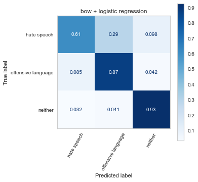

```python
fig, ax = plt.subplots(figsize=(5, 5))
ax.grid(False)

plt.rc('font', size=10)
plt.title('bow + logistic regression')
plot_confusion_matrix(gscv.best_estimator_, X_test, y_test, normalize='true',
                      display_labels=label_meaning.values(), ax=ax,
                      cmap=plt.cm.Blues, xticks_rotation=60);
```

#### Feature Importance

```python
%%capture

viz = FeatureImportances(gscv.best_estimator_['clf'], absolute=False)
viz.fit(X_train, y_train)
viz.features_ = [bow_inverse_vocab[i] for i in viz.features_]
```

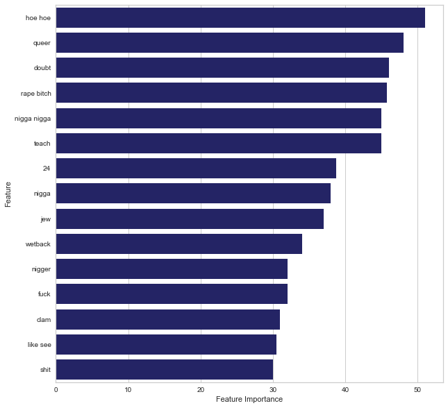

```python
plot_n_most_important_features(viz, n=15)
```

### 1.2) Bag-of-Words + Random forest

```python
gscv_rf = random_forest_gscv(X_train, y_train, file_path='results/rf_count.gscv')
```

```
Fitting 5 folds for each of 5 candidates, totalling 25 fits
```

```
[Parallel(n_jobs=-1)]: Using backend LokyBackend with 8 concurrent workers.
[Parallel(n_jobs=-1)]: Done  23 out of  25 | elapsed:   27.3s remaining:    2.4s
[Parallel(n_jobs=-1)]: Done  25 out of  25 | elapsed:   27.3s finished
```

```python
print(f'Best parameters: {gscv_rf.best_params_}')
print('Best estimator classification report:')
print(classification_report(y_test, gscv_rf.predict(X_test),
                            target_names=label_meaning.values()))
```

```
Best parameters: {'clf__max_depth': 10}
Best estimator classification report:
                    precision    recall  f1-score   support

       hate speech       0.33      0.66      0.44       286
offensive language       0.98      0.84      0.90      3838
           neither       0.72      0.95      0.82       833

          accuracy                           0.85      4957
         macro avg       0.68      0.82      0.72      4957
      weighted avg       0.90      0.85      0.86      4957
```

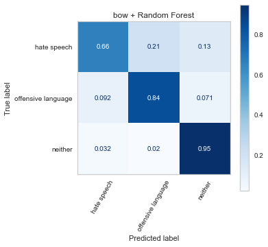

```python
fig, ax = plt.subplots(figsize=(5, 5))
ax.grid(False)

plt.rc('font', size=10)
plt.title('bow + Random Forest')
plot_confusion_matrix(gscv_rf.best_estimator_, X_test, y_test, normalize='true',
                      display_labels=label_meaning.values(), ax=ax,
                      cmap=plt.cm.Blues, xticks_rotation=60);
```

#### Feature Importance

```python
%%capture

viz = FeatureImportances(gscv_rf.best_estimator_['clf'], absolute=False)
viz.fit(X_train, y_train)
viz.features_ = [bow_inverse_vocab[i] for i in viz.features_]
```

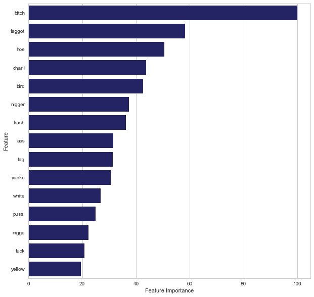

```python
plot_n_most_important_features(viz, n=15)
```

### 1.3) Bag-of-Words + Gradient Boosting

```python
gscv_gb = gradient_boosting_gscv(X_train, y_train, file_path='results/gb_count.gscv')
```

```
Fitting 5 folds for each of 6 candidates, totalling 30 fits
```

```
[Parallel(n_jobs=-1)]: Using backend LokyBackend with 8 concurrent workers.
[Parallel(n_jobs=-1)]: Done  30 out of  30 | elapsed:   18.1s finished
```

```python
print(f'Best parameters: {gscv_gb.best_params_}')
print('Best estimator classification report:')
print(classification_report(y_test, gscv_gb.predict(X_test),
                            target_names=label_meaning.values()))
```

```
Best parameters: {'clf__learning_rate': 1}
Best estimator classification report:
                    precision    recall  f1-score   support

       hate speech       0.26      0.20      0.22       286
offensive language       0.92      0.93      0.92      3838
           neither       0.81      0.82      0.81       833

          accuracy                           0.87      4957
         macro avg       0.66      0.65      0.65      4957
      weighted avg       0.86      0.87      0.86      4957
```

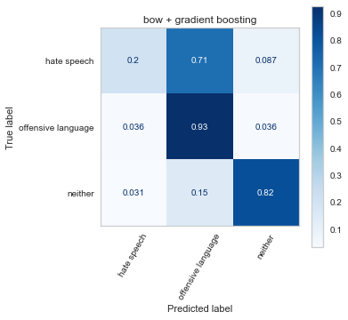

```python
fig, ax = plt.subplots(figsize=(5, 5))
ax.grid(False)

plt.rc('font', size=10)
plt.title('bow + gradient boosting')
plot_confusion_matrix(gscv_gb.best_estimator_, X_test, y_test, normalize='true',
                      display_labels=label_meaning.values(), ax=ax,
                      cmap=plt.cm.Blues, xticks_rotation=60);
```

#### Feature Importance

```python
%%capture

viz = FeatureImportances(gscv_gb.best_estimator_['clf'], absolute=False)
viz.fit(X_train, y_train)
viz.features_ = [bow_inverse_vocab[i] for i in viz.features_]
```

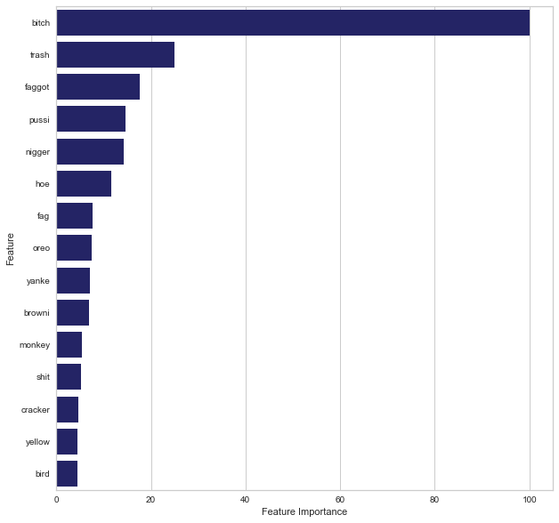

```python
plot_n_most_important_features(viz, n=15)
```

## 2) TF-IDF representation

```python
X_train, X_test, y_train, y_test = train_test_split(
    tfidf_vect.fit_transform(df['tweet']),
    df['class'],
    test_size=0.2,
    random_state=RANDOM_STATE,
    stratify=df['class']
)
```

```python
tfidf_inverse_vocab = {v: k for k,v in tfidf_vect.vocabulary_.items()}
```

### 2.1) TF-IDF + Logistic regression

```python
gscv = logistic_regression_gscv(X_train, y_train, file_path='results/logreg_tfidf.gscv')
```

```
Fitting 5 folds for each of 5 candidates, totalling 25 fits
```

```
[Parallel(n_jobs=-1)]: Using backend LokyBackend with 8 concurrent workers.
[Parallel(n_jobs=-1)]: Done  23 out of  25 | elapsed:    7.1s remaining:    0.6s
[Parallel(n_jobs=-1)]: Done  25 out of  25 | elapsed:    7.8s finished
```

```python
print(f'Best parameters: {gscv.best_params_}')
print('Best estimator classification report:')
print(classification_report(y_test, gscv.predict(X_test),
                            target_names=label_meaning.values()))
```

```
Best parameters: {'clf__C': 0.01}
Best estimator classification report:
                    precision    recall  f1-score   support

       hate speech       0.34      0.63      0.44       286
offensive language       0.97      0.87      0.92      3838
           neither       0.79      0.93      0.86       833

          accuracy                           0.87      4957
         macro avg       0.70      0.81      0.74      4957
      weighted avg       0.90      0.87      0.88      4957
```

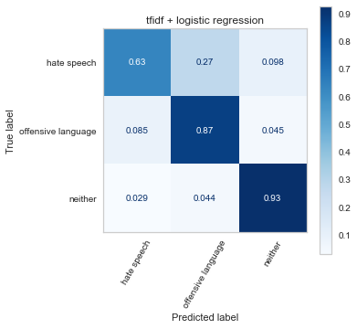

```python
fig, ax = plt.subplots(figsize=(5, 5))
ax.grid(False)

plt.rc('font', size=10)
plt.title('tfidf + logistic regression')
plot_confusion_matrix(gscv.best_estimator_, X_test, y_test, normalize='true',
                      display_labels=label_meaning.values(), ax=ax,
                      cmap=plt.cm.Blues, xticks_rotation=60);
```

#### Feature Importance

```python
%%capture

viz = FeatureImportances(gscv.best_estimator_['clf'], absolute=False)
viz.fit(X_train, y_train)
viz.features_ = [bow_inverse_vocab[i] for i in viz.features_]
```

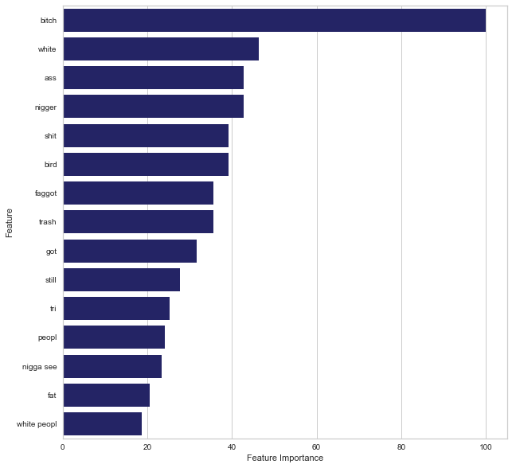

```python
plot_n_most_important_features(viz, n=15)
```

### 2.2) TF-IDF + Random forest

```python
gscv_rf = random_forest_gscv(X_train, y_train, file_path='results/rf_tfidf.gscv')
```

```
Fitting 5 folds for each of 5 candidates, totalling 25 fits
```

```
[Parallel(n_jobs=-1)]: Using backend LokyBackend with 8 concurrent workers.
[Parallel(n_jobs=-1)]: Done  23 out of  25 | elapsed:   24.9s remaining:    2.2s
[Parallel(n_jobs=-1)]: Done  25 out of  25 | elapsed:   25.0s finished
```

```python
print(f'Best parameters: {gscv_rf.best_params_}')
print('Best estimator classification report:')
print(classification_report(y_test, gscv_rf.predict(X_test),
                            target_names=label_meaning.values()))
```

```
Best parameters: {'clf__max_depth': 10}
Best estimator classification report:
                    precision    recall  f1-score   support

       hate speech       0.33      0.66      0.44       286
offensive language       0.98      0.84      0.90      3838
           neither       0.72      0.95      0.82       833

          accuracy                           0.85      4957
         macro avg       0.68      0.82      0.72      4957
      weighted avg       0.90      0.85      0.86      4957
```

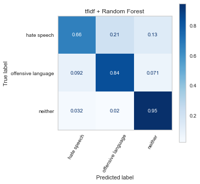

```python
fig, ax = plt.subplots(figsize=(5, 5))
ax.grid(False)

plt.rc('font', size=10)
plt.title('tfidf + Random Forest')
plot_confusion_matrix(gscv_rf.best_estimator_, X_test, y_test, normalize='true',
                      display_labels=label_meaning.values(), ax=ax,
                      cmap=plt.cm.Blues, xticks_rotation=60);
```

#### Feature Importance

```python
%%capture

viz = FeatureImportances(gscv_rf.best_estimator_['clf'], absolute=False)
viz.fit(X_train, y_train)
viz.features_ = [bow_inverse_vocab[i] for i in viz.features_]
```

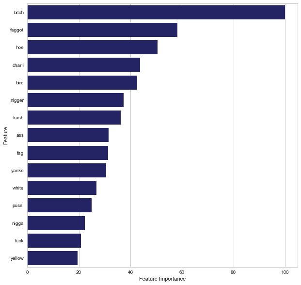

```python
plot_n_most_important_features(viz, n=15)
```

### 2.3) TF-IDF + Gradient boosting

```python
gscv_gb = gradient_boosting_gscv(X_train, y_train, file_path='results/gb_tfidf.gscv')
```

```
Fitting 5 folds for each of 6 candidates, totalling 30 fits
```

```
[Parallel(n_jobs=-1)]: Using backend LokyBackend with 8 concurrent workers.
[Parallel(n_jobs=-1)]: Done  30 out of  30 | elapsed:   19.0s finished
```

```python
print(f'Best parameters: {gscv_gb.best_params_}')
print('Best estimator classification report:')
print(classification_report(y_test, gscv_gb.predict(X_test),
                            target_names=label_meaning.values()))
```

```
Best parameters: {'clf__learning_rate': 1}
Best estimator classification report:
                    precision    recall  f1-score   support

       hate speech       0.26      0.20      0.22       286
offensive language       0.92      0.93      0.92      3838
           neither       0.81      0.82      0.81       833

          accuracy                           0.87      4957
         macro avg       0.66      0.65      0.65      4957
      weighted avg       0.86      0.87      0.86      4957
```

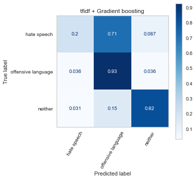

```python
fig, ax = plt.subplots(figsize=(5, 5))
ax.grid(False)

plt.rc('font', size=10)
plt.title('tfidf + Gradient boosting')
plot_confusion_matrix(gscv_gb.best_estimator_, X_test, y_test, normalize='true',
                      display_labels=label_meaning.values(), ax=ax,
                      cmap=plt.cm.Blues, xticks_rotation=60);
```

#### Feature Importance

```python
%%capture

viz = FeatureImportances(gscv_gb.best_estimator_['clf'], absolute=False)
viz.fit(X_train, y_train)
viz.features_ = [bow_inverse_vocab[i] for i in viz.features_]
```

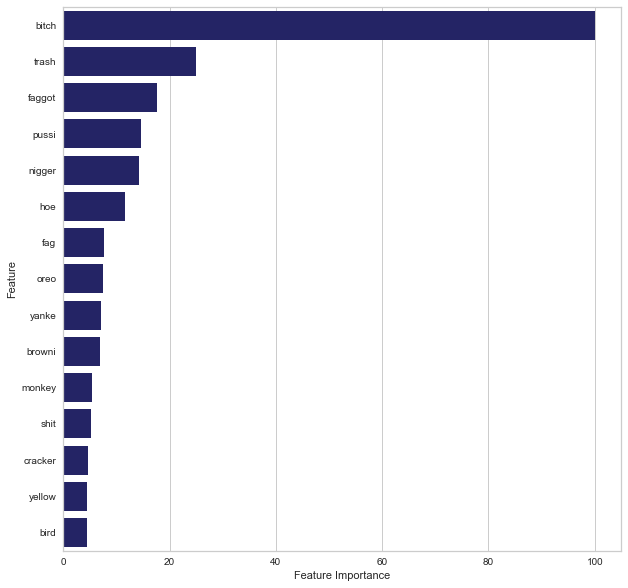

```python
plot_n_most_important_features(viz, n=15)
```

## 3) Word2Vec representation

```python
X_train, X_test, y_train, y_test = train_test_split(
    w2v_tweets,
    df['class'],
    test_size=0.2,
    random_state=RANDOM_STATE,
    stratify=df['class']
)
```

### 3.1) Word2Vec + Logistic regression

```python
gscv = logistic_regression_gscv(X_train, y_train, file_path='results/logreg_w2v.gscv')
```

```
Fitting 5 folds for each of 5 candidates, totalling 25 fits
```

```
[Parallel(n_jobs=-1)]: Using backend LokyBackend with 8 concurrent workers.
[Parallel(n_jobs=-1)]: Done  23 out of  25 | elapsed:   54.3s remaining:    4.7s
[Parallel(n_jobs=-1)]: Done  25 out of  25 | elapsed:   58.1s finished
```

```python
print(f'Best parameters: {gscv.best_params_}')
print('Best estimator classification report:')
print(classification_report(y_test, gscv.predict(X_test),
                            target_names=label_meaning.values()))
```

```
Best parameters: {'clf__C': 10}
Best estimator classification report:
                    precision    recall  f1-score   support

       hate speech       0.22      0.66      0.33       286
offensive language       0.97      0.78      0.86      3838
           neither       0.73      0.91      0.81       833

          accuracy                           0.79      4957
         macro avg       0.64      0.78      0.67      4957
      weighted avg       0.89      0.79      0.82      4957
```

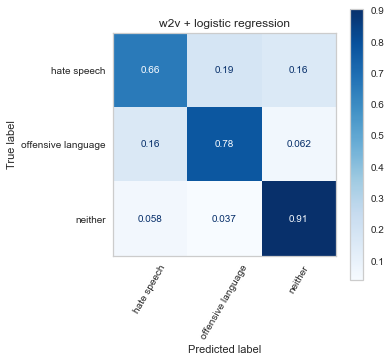

```python
fig, ax = plt.subplots(figsize=(5, 5))
ax.grid(False)

plt.rc('font', size=10)
plt.title('w2v + logistic regression')
plot_confusion_matrix(gscv.best_estimator_, X_test, y_test, normalize='true',
                      display_labels=label_meaning.values(), ax=ax,
                      cmap=plt.cm.Blues, xticks_rotation=60);
```

### 3.2) Word2Vec + Random forest

```python
gscv_rf = random_forest_gscv(X_train, y_train, file_path='results/rf_w2v.gscv')
```

```
Fitting 5 folds for each of 5 candidates, totalling 25 fits
```

```
[Parallel(n_jobs=-1)]: Using backend LokyBackend with 8 concurrent workers.
[Parallel(n_jobs=-1)]: Done  23 out of  25 | elapsed:  3.3min remaining:   17.4s
[Parallel(n_jobs=-1)]: Done  25 out of  25 | elapsed:  3.7min finished
```

```python
print(f'Best parameters: {gscv_rf.best_params_}')
print('Best estimator classification report:')
print(classification_report(y_test, gscv_rf.predict(X_test),
                            target_names=label_meaning.values()))
```

```
Best parameters: {'clf__max_depth': 10}
Best estimator classification report:
                    precision    recall  f1-score   support

       hate speech       0.41      0.42      0.41       286
offensive language       0.93      0.90      0.92      3838
           neither       0.73      0.83      0.78       833

          accuracy                           0.86      4957
         macro avg       0.69      0.72      0.70      4957
      weighted avg       0.87      0.86      0.87      4957
```

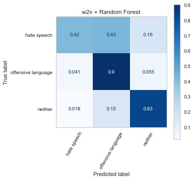

```python
fig, ax = plt.subplots(figsize=(5, 5))
ax.grid(False)

plt.rc('font', size=10)
plt.title('w2v + Random Forest')
plot_confusion_matrix(gscv_rf.best_estimator_, X_test, y_test, normalize='true',
                      display_labels=label_meaning.values(), ax=ax,
                      cmap=plt.cm.Blues, xticks_rotation=60);
```

### 3.3) Word2Vec + Gradient boosting

```python
gscv_gb = gradient_boosting_gscv(X_train, y_train, file_path='results/gb_w2v.gscv')
```

```
Fitting 5 folds for each of 6 candidates, totalling 30 fits
```

```
[Parallel(n_jobs=-1)]: Using backend LokyBackend with 8 concurrent workers.
[Parallel(n_jobs=-1)]: Done  30 out of  30 | elapsed: 12.1min finished
```

```python
print(f'Best parameters: {gscv_gb.best_params_}')
print('Best estimator classification report:')
print(classification_report(y_test, gscv_gb.predict(X_test),
                            target_names=label_meaning.values()))
```

```
Best parameters: {'clf__learning_rate': 0.2}
Best estimator classification report:
                    precision    recall  f1-score   support

       hate speech       0.43      0.19      0.27       286
offensive language       0.91      0.95      0.93      3838
           neither       0.80      0.81      0.81       833

          accuracy                           0.88      4957
         macro avg       0.72      0.65      0.67      4957
      weighted avg       0.87      0.88      0.87      4957
```

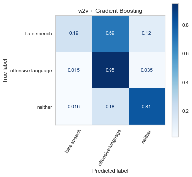

```python
fig, ax = plt.subplots(figsize=(5, 5))
ax.grid(False)

plt.rc('font', size=10)
plt.title('w2v + Gradient Boosting')
plot_confusion_matrix(gscv_gb.best_estimator_, X_test, y_test, normalize='true',
                      display_labels=label_meaning.values(), ax=ax,
                      cmap=plt.cm.Blues, xticks_rotation=60);
```

## Conclusion

The models seem to deliver very good results, especially when classifying "offensive language" and "neither" tweets.

The performance on "hate speech" is mediocre at best across models and representations. Gradient boosting performs quite badly here, as it often confuses "hate speech" tweets with "offensive language" tweets. The reason behind this, we assume, is the imbalanced data that we had $-$ only a few tweets had the label "hate speech", and there is a large similarity between the language used in that class and "offensive language", which makes it difficult for the models to differentiate between them.

The most important features always contain slurs or words frequently used in racist, sexist, and homophobic contexts, which can be expected due to the nature of the data set. Sexist slurs seems to be on top.

## Authors

The project group consisted of two members who collaborated on this notebook. The coding was roughly divided in half in the following way:

- Bruna Dujmovic - data exploration and preprocessing, feature extraction
- Nesrine Haddar - development of models and results analysis